# Projeto Integrador: GLM Binomial Logito

Luiz Gabriel de Souza

28/07/2021

# 1 Introdução

Vamos considerar a aplicação de um modelo linear generalizado com resposta binomial e função de ligação logito (regressão logística). Os dados são referentes a uma amostra de 699 nódulos de mama, e estão disponíveis na página da disciplina no arquivo breast.csv. O objetivo é ajustar um modelo preditivo, que permita classificá-los em benignos ou malignos com base num conjunto de covariáveis. As variáveis disponíveis na base são as seguintes:

# 2 Analise exploratória

## 2.1 Importando pacotes e dados

```r
suppressMessages(library(tidyverse))
suppressMessages(library(GGally))
suppressMessages(library(summarytools))
suppressMessages(library(corrplot))
suppressMessages(library(car))
suppressMessages(library(caret))
suppressMessages(library(pROC))
suppressMessages(library(effects))
suppressMessages(library(performance))
suppressMessages(library(kableExtra))
suppressMessages(library(gridExtra))



df <- read.table("breast.csv", header = T, sep = ";")
str(df)
```

```
## 'data.frame':    699 obs. of  4 variables:
##  $ CT   : int  5 5 3 6 4 8 1 2 2 4 ...
##  $ MA   : int  1 5 1 1 3 8 1 1 1 1 ...
##  $ BC   : int  3 3 3 3 3 9 3 3 1 2 ...
##  $ Class: chr  "benign" "benign" "benign" "benign" ...
```

## 2.2 Medidadas Resumo

As medidades resumos trazem informações básicas sobre os dados, como o valor mínimo, máximo, mediana, etc.

```r
summary(df)
```

```
##        CT               MA               BC            Class
##  Min.   : 1.000   Min.   : 1.000   Min.   : 1.000   Length:699
##  1st Qu.: 2.000   1st Qu.: 1.000   1st Qu.: 2.000   Class :character
##  Median : 4.000   Median : 1.000   Median : 3.000   Mode  :character
##  Mean   : 4.418   Mean   : 2.807   Mean   : 3.438
##  3rd Qu.: 6.000   3rd Qu.: 4.000   3rd Qu.: 5.000
##  Max.   :10.000   Max.   :10.000   Max.   :10.000
```

É possível observar que as variáveis explicativas são normalizadas, ou seja, possuem valor mínimo igual a 1 e valor máximo igual a 10.

## 2.3 Distribuição dos dados

### 2.3.1 Boxplots

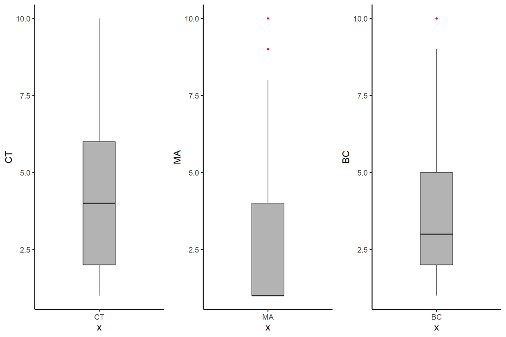

```r
bp1 <- ggplot(data = df, aes(x = "CT", y = CT)) +
        geom_boxplot(width = .3, outlier.colour = "red", fill="grey70")+
        theme_classic(base_size = 16)
bp2 <- ggplot(data = df, aes(x = "MA", y = MA)) +
        geom_boxplot(width = .3, outlier.colour = "red", fill="grey70")+
        theme_classic(base_size = 16)
bp3 <- ggplot(data = df, aes(x = "BC", y = BC)) +
        geom_boxplot(width = .3, outlier.colour = "red", fill="grey70") +
        theme_classic(base_size = 16)

# Organiza os gráfica um ao lado do outro
grid.arrange(bp1, bp2, bp3, ncol=3)
```

As variáveis **MA** e **BC**, possuem alguns outliers positivos. Além disso, a variável **MA**, possui uma mediana deslocada do centro do Boxplot, o que indica uma maior concentração dos dados.

### 2.3.2 Histogramas

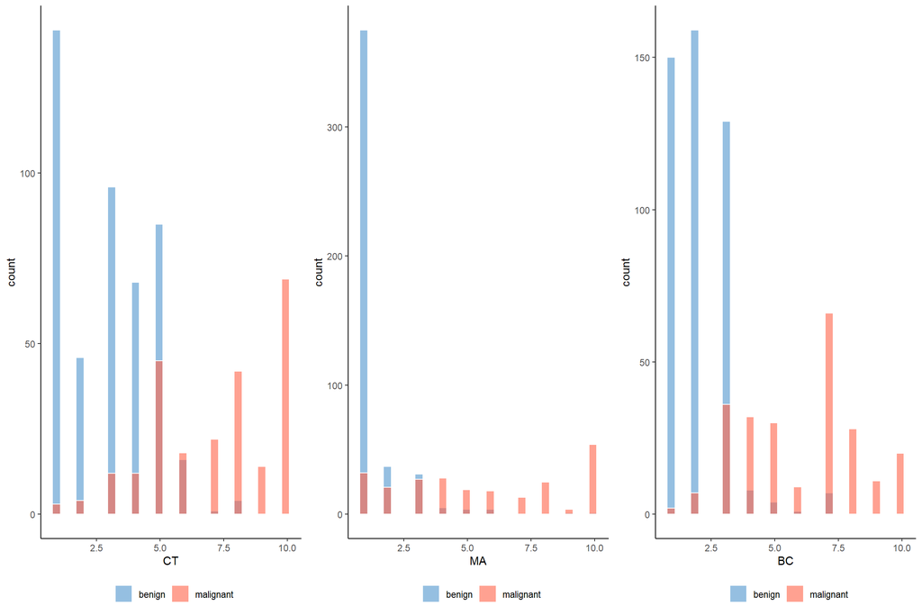

```r
hg1 <- ggplot(df, aes(x=CT, fill=Class)) +
         geom_histogram( color="white", alpha=0.6, position = 'identity') +
         scale_fill_manual(values=c("steelblue3", "tomato")) +
         theme_classic() +
         labs(fill="")+
         theme(legend.position="bottom")

hg2 <- ggplot(df, aes(x=MA, fill=Class)) +
        geom_histogram( color="white", alpha=0.6, position = 'identity') +
        scale_fill_manual(values=c("steelblue3", "tomato")) +
        theme_classic() +
        labs(fill="")+
        theme(legend.position="bottom")

hg3 <- ggplot(df, aes(x=BC, fill=Class)) +
        geom_histogram( color="white", alpha=0.6, position = 'identity') +
        scale_fill_manual(values=c("steelblue3", "tomato")) +
        theme_classic() +
        labs(fill="") +
        theme(legend.position="bottom")

# Organiza os gráfica um ao lado do outro
grid.arrange(hg1, hg2, hg3, ncol=3)
```

### 2.3.3 Boxplots por tipo de nódulo

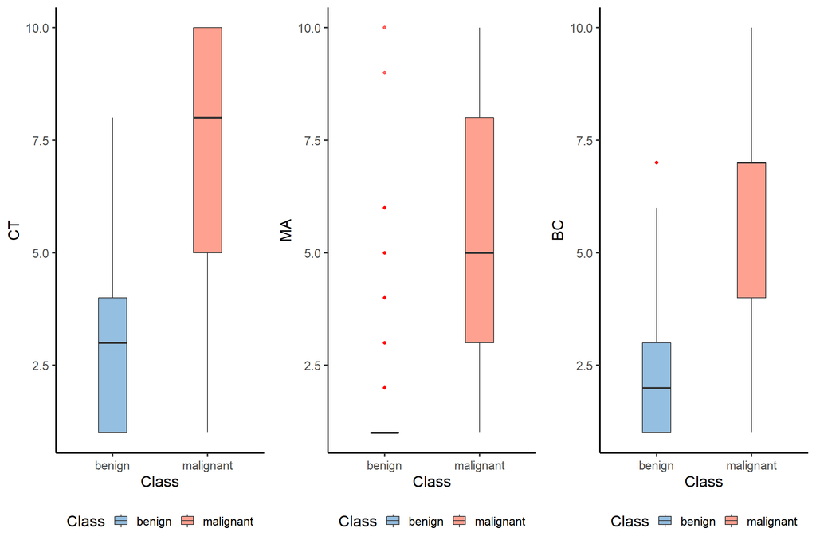

```r
bp1 <- ggplot(data = df, aes(x = Class, y = CT, fill = Class)) +
        geom_boxplot(width = .3, outlier.colour = "red", alpha=0.6)+
        scale_fill_manual(values=c("steelblue3", "tomato"))+
        theme_classic(base_size = 16)+
        theme(legend.position="bottom")

bp2 <- ggplot(data = df, aes(x = Class, y = MA, fill = Class)) +
        geom_boxplot(width = .3, outlier.colour = "red", alpha=0.6)+
        scale_fill_manual(values=c("steelblue3", "tomato"))+
        theme_classic(base_size = 16)+
        theme(legend.position="bottom")

bp3 <- ggplot(data = df, aes(x = Class, y = BC, fill = Class)) +
        geom_boxplot(width = .3, outlier.colour = "red", alpha=0.6)+
        scale_fill_manual(values=c("steelblue3", "tomato"))+
        theme_classic(base_size = 16)+
        theme(legend.position="bottom")

# Organiza os gráfica um ao lado do outro
grid.arrange(bp1, bp2, bp3, ncol=3)
```

O boxplot quebrado por tipo de nódulo indica que a concentração dos dados de nódulos benignos na ditribuição da variável **MA** geram outliers para essa classe. Além disso, indica os nódulos malignos apresentam mediana maior para todas as variáveis, indicando influência positiva no diagnóstico de um tumor quando as variáveis possuem valores maiores.

## 2.4 Correlograma

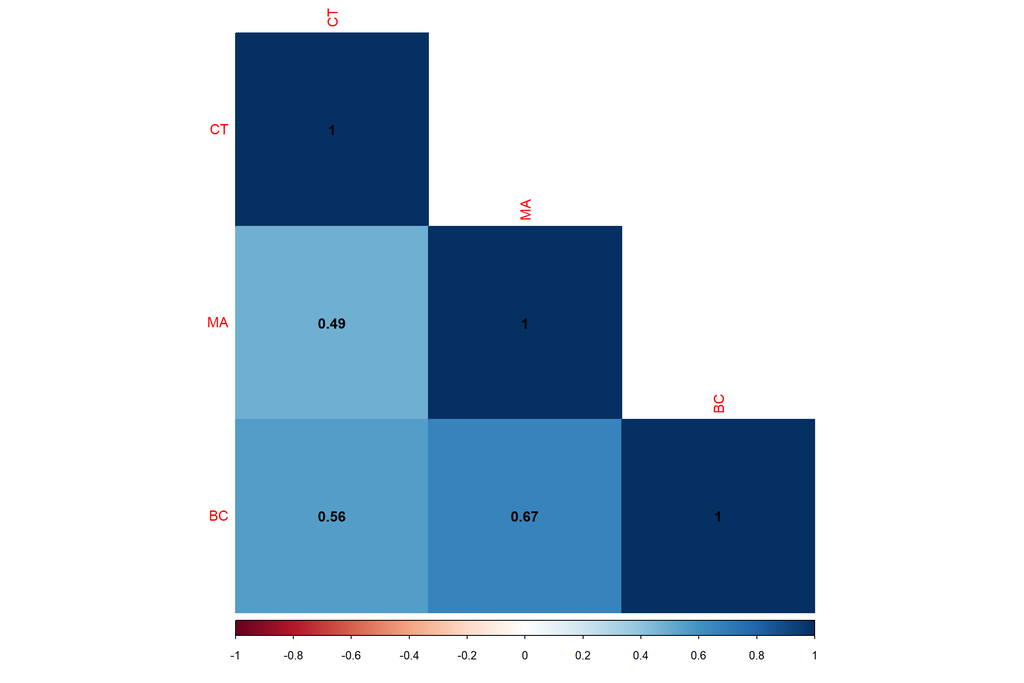

```r
cor <-  cor(df[,-4])
corrplot(cor, method="color", type='lower', addCoef.col = "black")
```

A matrix de correlação acima indica correlação positiva entre todas as variáveis, com destaque maior para a relação entre as variáveis **MA** e **BC**. Como as correlações não são tão extremas (>80%), veremos nas análises dos resíduos se teremos a presença de multicolineridade entre as variáveis.

# 3 Fit do modelo: base de treino

## 3.1 Separa treino e teste

Para fins preditivos, vamos separar, aleatoriamente, a base em duas (a primeira, com aproximadamente 75% dos dados, para o ajuste, e a outra, com os demais dados, para avalidação). Ajuste o modelo de regressão logística com os dados da primeira amostra.

```r
# Transformação da variável texto para numérica
df <- df %>%
        mutate(Class = case_when(Class == "benign" ~ 0,
                                 Class != "benign" ~ 1))
```

```r
# Escolha da semente aleatório para garantir reproducibilidade
set.seed(1909)

# Separação de treino e teste
indice_treino = createDataPartition(y=df$Class, p=0.75, list=FALSE)
treino = df[indice_treino, ]
teste = df[-indice_treino, ]
```

## 3.2 Acurácia, Sensibilidade e Especificidade.

### 3.2.1 Definições:

Antes de calcularmos tais métricas, vale uma breve definição das mesmas:

### 3.2.2 Fit da modelo

Vamos utilizar o pacote *stats* para treinar o modelo, com a familia Binomial e função de ligação logit (regressão logística.

```r
# Fit do modelo com os dados de treino
m1 <- glm(Class ~ .,data = treino, family = binomial(link='logit'))
summary(m1)
```

```
##
## Call:
## glm(formula = Class ~ ., family = binomial(link = "logit"), data = treino)
##
## Deviance Residuals:
##     Min       1Q   Median       3Q      Max
## -4.0442  -0.1508  -0.0283   0.0103   2.6016
##
## Coefficients:
##             Estimate Std. Error z value Pr(>|z|)
## (Intercept) -11.8805     1.4318  -8.298  < 2e-16 ***
## CT            1.1211     0.1702   6.588 4.45e-11 ***
## MA            0.5544     0.1008   5.498 3.84e-08 ***
## BC            1.1917     0.1900   6.272 3.56e-10 ***
## ---
## Signif. codes:  0 '***' 0.001 '**' 0.01 '*' 0.05 '.' 0.1 ' ' 1
##
## (Dispersion parameter for binomial family taken to be 1)
##
##     Null deviance: 673.75  on 524  degrees of freedom
## Residual deviance: 109.01  on 521  degrees of freedom
## AIC: 117.01
##
## Number of Fisher Scoring iterations: 8
```

```r
# Armazenando os coeficientes encontrados a nível do preditor (log-odds)
CT_estimate_m1 <- as.character(round(m1$coefficients[2],3))
MA_estimate_m1 <- as.character(round(m1$coefficients[3],3))
BC_estimate_m1 <- as.character(round(m1$coefficients[4],3))

# Armazenando os coeficientes encontrados a nível da resposta (odds)
CT_estimate_m1_exp <- as.character(round(exp(m1$coefficients[2]),3))
MA_estimate_m1_exp <- as.character(round(exp(m1$coefficients[3]),3))
BC_estimate_m1_exp <- as.character(round(exp(m1$coefficients[4]),3))
```

É possível observar que todas as variáveis apresentaram significância estatística, com um erro padrão baixo e contribuem para o modelo com estimadores positivos. A log-chance de ser um nódulo maligno aumenta 1.121 e 1.192 para cada 1 unidade a mais nas variáveis **CT** e **BC**, respectivamente. Da mesma maneira, realizando a tranforção dos resultados em termos de log-chance para chance aplicando o exponencial, é possível dizer que um nódulo maligno aumenta 3.068 e 3.293 para cada 1 unidade a mais nas variáveis **CT** e **BC**, respectivamente.

### 3.2.3 Criação da função para testes

Para obter os dados preditos e testar para diferentes níveis de *threshold* (corte), criarei uma função para facilitar o trabalho repetitivo que recebe como parâmetro o próprio *threshold* e o tipo de dado que será usado no calculo, base de treino ou a base de teste. Lembrando que o modelo foi computado(fit) com a base treino.

```r
# Função para predict de diferentes threshoulds e treino/teste
pred_m1 <- function(p, tipo){
                  if (tipo == "treino"){
                pred_treino_prob <- predict(m1, newdata = treino[,-4], type = 'response')
                pred_treino <- ifelse(pred_treino_prob > p, 1, 0)
                cfm_treino <- confusionMatrix(data=factor(pred_treino), reference = factor(treino[,4])) #mode = "prec_recall"
                return(cfm_treino)
                  }
                  if (tipo == "teste"){
                pred_teste_prob <- predict(m1, newdata = teste[,-4], type = 'response')
                pred_teste <- ifelse(pred_teste_prob > p, 1, 0)
                cfm_teste <- confusionMatrix(data=factor(pred_teste), reference = factor(teste[,4])) #mode = "prec_recall"
                return(cfm_teste)
              }
}

# Função para imprimir tabela estilizado no documento html
metrics_m1 <- function(p, tipo) {
  metricas <- data.frame(Acurácia = round(pred_m1(p=p,tipo=tipo)$overall["Accuracy"],4),
                         Sensibilidade = round(pred_m1(p=p,tipo=tipo)$byClass["Sensitivity"],4),
                         Especificidade = round(pred_m1(p=p,tipo=tipo)$byClass["Specificity"],4),
                         row.names = NULL) %>%
              kbl() %>%
              kable_material_dark(c("striped", "hover"))
  return(metricas)
}
```

### 3.2.4 Testando *thresholds*

### 3.2.5 p>0.1

#### 3.2.5.1 Treino

```r
metrics_m1(0.1,"treino")
```

| Acurácia | Sensibilidade | Especificidade |
| --- | --- | --- |
| 0.9181 | 0.8815 | 0.9888 |

#### 3.2.5.2 Teste

```r
metrics_m1(0.1,"teste")
```

| Acurácia | Sensibilidade | Especificidade |
| --- | --- | --- |
| 0.8966 | 0.8482 | 0.9839 |

### 3.2.6 p>0.3

#### 3.2.6.1 Treino

```r
metrics_m1(0.3,"treino")
```

| Acurácia | Sensibilidade | Especificidade |
| --- | --- | --- |
| 0.9657 | 0.9682 | 0.9609 |

#### 3.2.6.2 Teste

```r
metrics_m1(0.3,"teste")
```

| Acurácia | Sensibilidade | Especificidade |
| --- | --- | --- |
| 0.9368 | 0.9375 | 0.9355 |

### 3.2.7 p>0.5

#### 3.2.7.1 Treino

```r
metrics_m1(0.5,"treino")
```

| Acurácia | Sensibilidade | Especificidade |
| --- | --- | --- |
| 0.9676 | 0.9769 | 0.9497 |

#### 3.2.7.2 Teste

```r
metrics_m1(0.5,"teste")
```

| Acurácia | Sensibilidade | Especificidade |
| --- | --- | --- |
| 0.931 | 0.9375 | 0.9194 |

### 3.2.8 p>0.7

#### 3.2.8.1 Treino

```r
metrics_m1(0.7,"treino")
```

| Acurácia | Sensibilidade | Especificidade |
| --- | --- | --- |
| 0.9524 | 0.9855 | 0.8883 |

#### 3.2.8.2 Teste

```r
metrics_m1(0.7,"teste")
```

| Acurácia | Sensibilidade | Especificidade |
| --- | --- | --- |
| 0.9138 | 0.9554 | 0.8387 |

### 3.2.9 p>0.9

#### 3.2.9.1 Treino

```r
metrics_m1(0.9,"treino")
```

| Acurácia | Sensibilidade | Especificidade |
| --- | --- | --- |
| 0.9295 | 0.9913 | 0.8101 |

#### 3.2.9.2 Teste

```r
metrics_m1(0.9,"teste")
```

| Acurácia | Sensibilidade | Especificidade |
| --- | --- | --- |
| 0.8908 | 0.9643 | 0.7581 |

## 3.3 Curva ROC

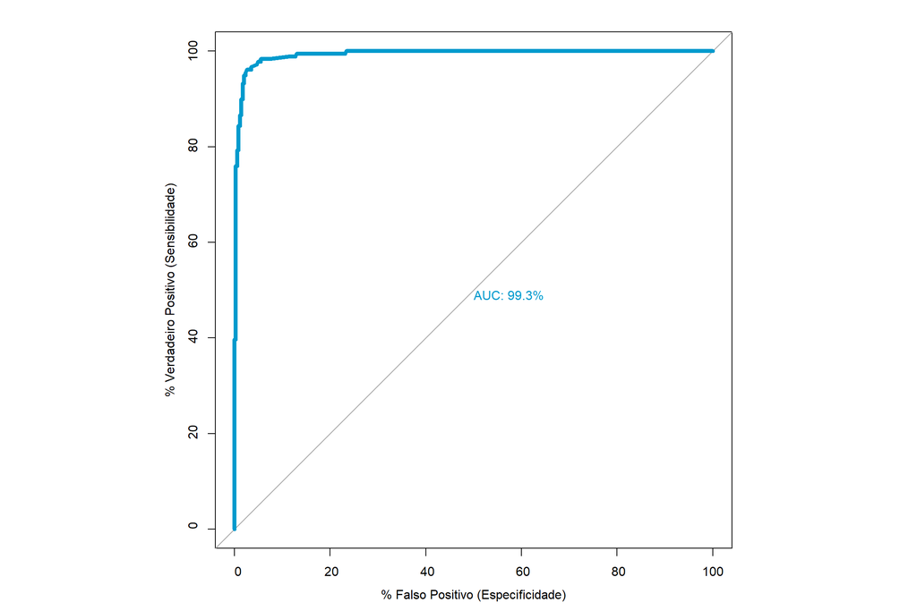

```
##
## Call:
## roc.default(response = treino[, 4], predictor = fitted(m1), percent = TRUE,     plot = TRUE, legacy.axes = TRUE, xlab = "% Falso Positivo (Especificidade)",     ylab = "% Verdadeiro Positivo (Sensibilidade)", lwd = 5,     col = "deepskyblue3", print.auc = TRUE)
##
## Data: fitted(m1) in 346 controls (treino[, 4] 0) < 179 cases (treino[, 4] 1).
## Area under the curve: 99.29%
```

```r
par(pty="s")
roc(treino[,4], fitted(m1), plot=TRUE, legacy.axes=TRUE, percent=TRUE,
    xlab="% Falso Positivo (Especificidade)", ylab="% Verdadeiro Positivo (Sensibilidade)",
    lwd=5, col="deepskyblue3", print.auc=TRUE)
```

```r
#par(pty="s")
#roc(treino[,4], fitted(m1), plot=TRUE, legacy.axes=TRUE, percent=TRUE,
#    xlab="% Falso Positivo", ylab="% Verdadeiro Positivo",
#    lwd=5, col="deepskyblue3", print.auc=TRUE)

# SObreponto a curva de outra modelo para comparação
#plot.roc(treino[,4]^2, fitted(m1)^3, add=TRUE, percent=TRUE,
    #lwd=1, col="green", print.auc=TRUE, print.auc.y=40)
#legend("bottomright", legend=c("m1","m2"), col=c("deepskyblue3","green"), lwd =4)

par(pty="m")
```

## 3.4 Teste de Prevalência e Razão de custos

Utilizando os dados de teste (25% da base total), vamos testar diferentes valores de prevalência (proporção de nódulos malignos na população) e atribuir diferentes razões de custo para ponderar quantas vezes um falso negativo é mais “caro” que um falso positivo, e encontrar quais seriam os *thresholds* ideais em cada cenário.

Vamos testar as seguintes combinações de Prevalência e Razão de Custo:

- 1. Prevalência = 0.5; razão de custos =2
- 2. Prevalência = 0.2; razão de custos =2
- 3. Prevalência = 0.5; razão de custos =10
- 4. Prevalência = 0.2; razão de custos =2

```r
teste_pred <- predict(m1, newdata = teste[,-4], type = 'response')
r2 <- roc(teste$Class, teste_pred)
i <- coords(roc = r2, x = "best", ret = c("threshold"), best.method = "youden", best.weights=c(2, 0.5))
ii <- coords(roc = r2, x = "best", ret = c("threshold"), best.method = "youden", best.weights=c(2, 0.2))
iii <- coords(roc = r2, x = "best", ret = c("threshold"), best.method = "youden", best.weights=c(10, 0.5))
iv <- coords(roc = r2, x = "best", ret = c("threshold"), best.method = "youden", best.weights=c(2, 0.2))
```

Neste caso, a melhor regra de classificação (ponto de corte) para cada cenário é apresentada abaixo :

```r
cenarios_df <- data.frame(cenário = c("i", "ii", "iii", "iv"), p = c(i[[1]], ii[[1]], iii[[1]], iv[[1]]))
cenarios_df %>%
  kbl() %>%
  kable_material_dark(c("striped", "hover"))
```

| cenário | p |
| --- | --- |
| i | 0.1439857 |
| ii | 0.2711256 |
| iii | 0.1439857 |
| iv | 0.2711256 |

# 4 Fit do modelo: base completa

## 4.1 Modelo ajustado

Vamos rodar o modelo para a base toda, seguindo com as mesmas configurações de família e link.

```r
m2 <- glm(Class ~ .,data = df, family = binomial(link='logit'))
summary(m2)
```

```
##
## Call:
## glm(formula = Class ~ ., family = binomial(link = "logit"), data = df)
##
## Deviance Residuals:
##     Min       1Q   Median       3Q      Max
## -3.7385  -0.1974  -0.0548   0.0338   2.8695
##
## Coefficients:
##             Estimate Std. Error z value Pr(>|z|)
## (Intercept) -9.96623    0.90498 -11.013  < 2e-16 ***
## CT           0.90958    0.10950   8.307  < 2e-16 ***
## MA           0.53332    0.08632   6.178 6.48e-10 ***
## BC           0.95659    0.13240   7.225 5.02e-13 ***
## ---
## Signif. codes:  0 '***' 0.001 '**' 0.01 '*' 0.05 '.' 0.1 ' ' 1
##
## (Dispersion parameter for binomial family taken to be 1)
##
##     Null deviance: 900.53  on 698  degrees of freedom
## Residual deviance: 184.57  on 695  degrees of freedom
## AIC: 192.57
##
## Number of Fisher Scoring iterations: 7
```

```r
# Armazenando os coeficientes encontrados na escala do preditor (log-odds)
CT_estimate_m2 <- as.character(round(m2$coefficients[2],3))
MA_estimate_m2 <- as.character(round(m2$coefficients[3],3))
BC_estimate_m2 <- as.character(round(m2$coefficients[4],3))

df_estimate_m2 <- data.frame("CT"=CT_estimate_m2, "MA"=MA_estimate_m2, "BC"=BC_estimate_m2)


# Armazenando os coeficientes encontrados na escala da probabilidade das respostas (odds)
CT_estimate_m2_exp <- as.character(round(exp(m2$coefficients[2]),3))
MA_estimate_m2_exp <- as.character(round(exp(m2$coefficients[3]),3))
BC_estimate_m2_exp <- as.character(round(exp(m2$coefficients[4]),3))

df_estimate_m2_exp <- data.frame("CT"=CT_estimate_m2_exp, "MA"=MA_estimate_m2_exp, "BC"=BC_estimate_m2_exp)
```

Com o modelo treinado, temos os coeficientes do modelo na *escala do preditor* (*log-odds*) é expresso abaixo:

```r
df_estimate_m2 %>%
  kbl() %>%
  kable_material_dark(c("striped", "hover"))
```

| CT | MA | BC |
| --- | --- | --- |
| 0.91 | 0.533 | 0.957 |

Para a escala da resposta (*probabilidade*), após aplicado a tranformação exponecial dos dados antes em termos de log, temos os seguintes coeficientes:

```r
df_estimate_m2_exp %>%
  kbl() %>%
  kable_material_dark(c("striped", "hover"))
```

| CT | MA | BC |
| --- | --- | --- |
| 2.483 | 1.705 | 2.603 |

## 4.2 Análise do ajuste

É possível observar que todas as variáveis continuam apresentando significância estatísticas pelo teste de wald e com erros médios baixo. Além disso, apresentam uma mediana dos resíduos próxima de zero, o que indica que erros estão próximo da mediana, não apresentando desbalancemento dos erros. Todas as variáveis apresentam efeitos positivos, ou seja, para cada unidade a mais de cada uma das variáveis em conjunto, as chances de se obter um diagnóstico de um nódulo maligno é maior, em especial para as variáveis *CT* e *BC*.

- Para cada unidade a mais de *CT*, as chances do nódulo ser maligno aumenta para 2.483, fixado os valores das demais variáveis.
- Para cada unidade a mais de *MA*, as chances do nódulo ser maligno aumenta para 1.705, fixado os valores das demais variáveis.
- Para cada unidade a mais de *BC*, as chances do nódulo ser maligno aumenta para 2.603, fixado os valores das demais variáveis.

## 4.3 Intervalos de confiância

Na tabela abaixo temos os intervalos de confiância dos parâmetros em ambas as escalas: predito(logOR) e resposta(OR).

```r
conf_int_tb <- cbind(logOR = coef(m2), confint(m2),OR = exp(coef(m2)), exp(confint(m2))) #na escala do preditor e da resposta, respectivamente
conf_int_tb %>%
  kbl() %>%
  kable_material_dark(c("striped", "hover"))
```

|  | logOR | 2.5 % | 97.5 % | OR | 2.5 % | 97.5 % |
| --- | --- | --- | --- | --- | --- | --- |
| (Intercept) | -9.9662304 | -11.9256936 | -8.3553753 | 0.000047 | 0.0000066 | 0.0002351 |
| CT | 0.9095838 | 0.7109011 | 1.1427064 | 2.483289 | 2.0358249 | 3.1352422 |
| MA | 0.5333153 | 0.3741545 | 0.7155556 | 1.704574 | 1.4537617 | 2.0453227 |
| BC | 0.9565923 | 0.7133485 | 1.2350971 | 2.602812 | 2.0408135 | 3.4387125 |

## 4.4 Predict novo registro

Abaixo temos as chances e a probabilidades estimadas para o diagnósitco de um nódulo novo, que não foi utilizado no treino nem no teste, com os seguintes para as variáveis explicativas: CT = 5, MA = 3 e BC = 4.

A predição na escala do preditor(log) é:

```r
new_predict_preditor <- predict(m2, newdata = data.frame(CT = 5, MA = 3, BC = 4))

new_predict_preditor %>%
  kbl() %>%
  kable_material_dark(c("striped", "hover"))
```

| x |
| --- |
| 0.0080037 |

Enquanto que a predição na escala da resposta (probabilidade) é:

```r
new_predict_resposta <- predict(m2, newdata = data.frame(CT = 5, MA = 3, BC = 4), type = "response") #predição na escala da resposta (probabilidade, inversa do link = logit)
new_predict_resposta %>%
  kbl() %>%
  kable_material_dark(c("striped", "hover", "responsive"))
```

| x |
| --- |
| 0.5020009 |

Ou seja, o diagnóstico nos dá uma probabilidade de que o nódulo seja maligno de 0.5020009. Se consideramos um **threshold** de 0,3, devemos classificar o nódulo como maligno, de acordo com o modelo ajustado.

## 4.5 Análise de diagnóstico

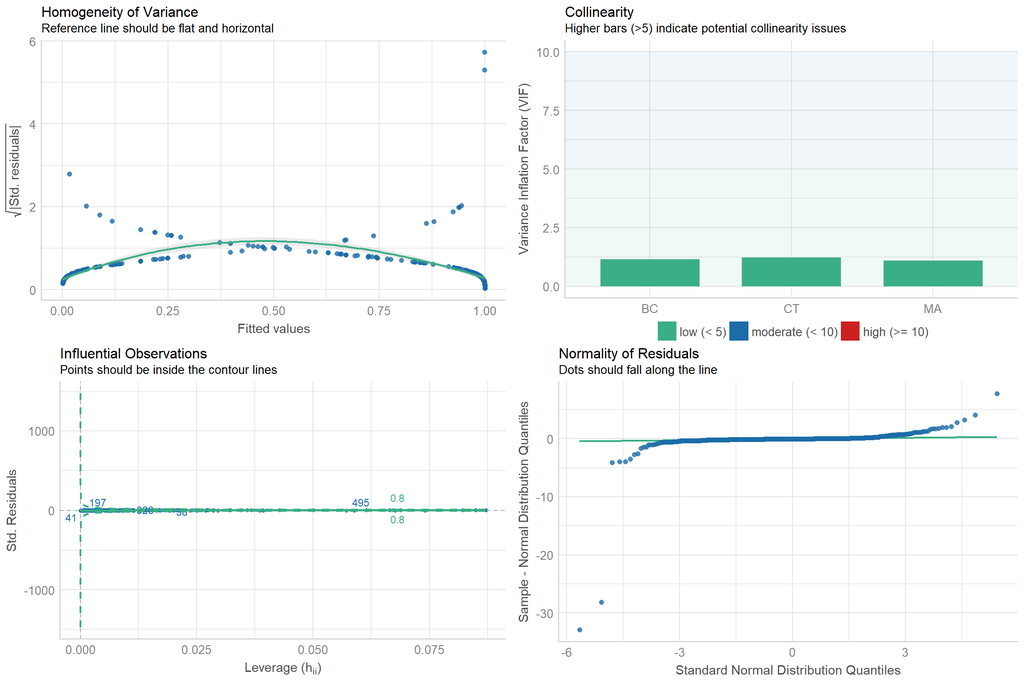

```r
check_model(m2)
```

# 5 Conclusão

Os ajustes realizaddos garantiram uma explicabilidade da variável de interesse com um nível significativo. Existem algumas melhorias que ainda podem ser feitas, como os outliers encontrados no gráfico da Homogeneidade da Variância mostrado na análise dos resíduos e uma análise mais detalhada da relação das variáveis em busca de relações não lineares. Tais análises podem melhorar ainda mais a performance do modelo.

Gostaria de deixar registrado que este projeto me ajudou muito a comprender melhor o processo de ajuste de um modelo de regressão logística, bem como a validação e testes do mesmo. Pude aplicar diversos conceitos estatísticos vistos em aula e entender melhor o grau de complexidade na composição de um modelo logito completo.

# 6 Referências

- Yihui Xie, J. J. Allaire, Garrett Grolemund. R Markdown: The Definitive Guide. [link](https://bookdown.org/yihui/rmarkdown/html-document.html#table-of-contents).
- A. Kassambara. [link](http://www.sthda.com/english/)
- Yukio. Separando a base de treino e teste no R. [link](https://estatsite.com.br/2018/08/18/separando-a-base-treino-e-teste-no-r/)
- Yan Holtz. [link](https://www.r-graph-gallery.com/)
- Colors in R. [link](http://www.stat.columbia.edu/~tzheng/files/Rcolor.pdf)
- Max Kuhn. The Caret Package. [link](https://topepo.github.io/caret/measuring-performance.html)
- confusionMatrix: Create a confusion matrix. [link](https://www.rdocumentation.org/packages/caret/versions/6.0-88/topics/confusionMatrix)
- Hao Zhu. Create Awesome HTML Table with knitr::kable and kableExtra. [link](https://cran.r-project.org/web/packages/kableExtra/vignettes/awesome_table_in_html.html#Installation)
- Josh Starmer. ROC and AUC in R. [link](https://www.youtube.com/watch?v=qcvAqAH60Yw)
- Jualiana Guamá. Métricas de avaliação de classificadores. [link](https://medium.com/pyladiesbh/m%C3%A9tricas-de-avalia%C3%A7%C3%A3o-de-classificadores-6aadc3dacd51)
- Doug Steen. Understanding the ROC Curve and AUC. [link](https://towardsdatascience.com/understanding-the-roc-curve-and-auc-dd4f9a192ecb)